# Caso Euromotors

Veamos también más detenidamente la cantidad de personas por valor del auto

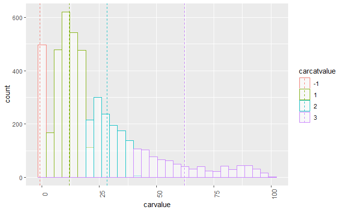

```r
std_values<-ddply(db,"carcatvalue",summarise,Min=min(carvalue),Max=max(carvalue),Mean=mean(carvalue),sd=sd(carvalue))


ggplot(db,aes(x=carvalue,color=carcatvalue))+geom_histogram(fill="white",alpha=0.5,position = "identity")+
  geom_vline(data = std_values,aes(xintercept=Mean,color=carcatvalue),linetype="dashed")+
  theme(axis.text.x = element_text(angle = 90,size = 10))
```

Podemos ver que a medida que crece el valor del auto, decrece la cantidad de personas que lo tienen.

*Datos generales*

Comparemos a las personas que tienen autos de lujo vs las que no, de acuerdo a las medias de sus valores numéricos

| lujo_si | mean(age) | median(age) | mean(ed) | mean(spoused) |
| --- | --- | --- | --- | --- |
| 0 | 45.58059 | 43 | 14.36368 | 6.000721 |
| 1 | 54.21266 | 55 | 15.43489 | 6.670251 |

Son personas de una edad mayor a las personas que no tienen autos de lujo. Además, su educación es un poco mayor en promedio, pero no tanto como para decir que es un rasgo preponderante.

Con el género y estado civil sucede algo similar. Se puede ver que la mayoría son mujeres y que el mayor estado civil es soltero; no obstante, la diferencia es muy pequeña:

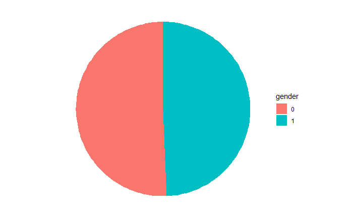

| gender | freq | percentage |
| --- | --- | --- |
| 0 | 424 | 50.65711 |
| 1 | 413 | 49.34289 |

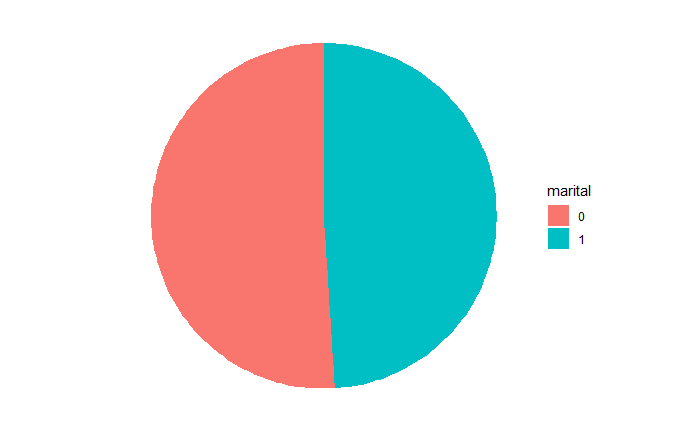

| marital | freq | percentage |
| --- | --- | --- |
| 0 | 427 | 51.01553 |
| 1 | 410 | 48.98447 |

```r
jcat<-db%>%group_by(lujo_si,jobcat)%>%summarise(count=n())
cast(jcat,jobcat~lujo_si,value = "count")
```

|  | jobcat | 0 | 1 |
| --- | --- | --- | --- |
| 1 | 1 | 1138 | 250 |
| 2 | 2 | 1520 | 120 |
| 3 | 3 | 478 | 142 |
| 4 | 4 | 170 | 42 |
| 5 | 5 | 346 | 106 |
| 6 | 6 | 511 | 177 |

*Datos de empleo e ingresos*

```r
db%>%group_by(lujo_si)%>%summarise(mean(income),mean(employ),mean(creddebt),mean(cardspent))
```

| lujo_si | mean(income) | mean(employ) | mean(creddebt) | mean(cardspent) |
| --- | --- | --- | --- | --- |
| 0 | 38.32933 | 8.44271 | 1.275004 | 308.4913 |
| 1 | 136.47909 | 16.13501 | 4.753626 | 480.0039 |

Otro rasgo característico de estas personas es que tienen unos sueldos muy altos (más de 136 000 al año) y están en el mismo trabajo desde hace 16 años (employ). El débito en sus tarjetas de crédito también es mayor.

Veamos también lo correspondiente a las tarjetas

```r
card_tb<-db%>%group_by(lujo_si,cardtype)%>%summarise(count=n())
cast(card_tb,cardtype~lujo_si,value = "count")
```

|  | cardtype | 0 | 1 |
| --- | --- | --- | --- |
| 1 | 1 | 1015 | 227 |
| 2 | 2 | 1055 | 186 |
| 3 | 3 | 1034 | 223 |
| 4 | 4 | 1059 | 201 |

Respecto a si realizan facturaciones electrónicas

```r
elect<-db%>%group_by(lujo_si,ebill)%>%summarise(count=n())
cast(elect,ebill~lujo_si,value = "count")
```

|  | ebill | 0 | 1 |
| --- | --- | --- | --- |
| 1 | 0 | 2722 | 535 |
| 2 | 1 | 1441 | 302 |

*Datos de publicidad*

```r
db%>%group_by(lujo_si)%>%summarise(mean(hourstv))
```

| lujo_si | mean(hourstv) |
| --- | --- |
| 0 | 19.58059 |
| 1 | 19.96535 |

```r
nw<-db%>%group_by(lujo_si,news)%>%summarise(count=n())
cast(nw,news~lujo_si,value = "count")
```

|  | news | 0 | 1 |
| --- | --- | --- | --- |
| 1 | 0 | 2308 | 329 |
| 2 | 1 | 1855 | 508 |

# 5. Planteamiento del modelo

Se plantea realizar un modelo de regresión logistica para predecir en base a las variables seleccionadas la posibilidad de que una persona posea un auto de lujo. Esto permitirá comprobar que las variables seleccionadas son las más adecuadas para el caso planteado

Ahora se pasará a tomar una muestra aleatoria del total

```r
#Se dividen los datos para entrenamiento (75% de train y 25% de test)

set.seed(88)
split=sample.split(db$lujo_si,SplitRatio = 0.75)


#Crear el training y testing data sets

dt=subset(db,split==TRUE)  #Train
de=subset(db,split==FALSE) #Test
```

Modelo de regresión

```r
RL_Eur<-glm(lujo_si~income+tollfree+cardtype+forward+ebill+cardspent+spoused+forward+jobcat+pets_reptiles,data=dt,family = binomial())
```

```
glm.fit: fitted probabilities numerically 0 or 1 occurred
```

```r
summary(RL_Eur)
```

```
Call:
glm(formula = lujo_si ~ income + tollfree + cardtype + forward +
    ebill + cardspent + spoused + forward + jobcat + pets_reptiles,
    family = binomial(), data = dt)

Deviance Residuals:
    Min       1Q   Median       3Q      Max
-5.7045  -0.2479  -0.1289  -0.0767   2.3865

Coefficients:
                Estimate Std. Error z value Pr(>|z|)
(Intercept)   -6.5825378  0.3171776 -20.753  < 2e-16 ***
income         0.0724357  0.0030602  23.670  < 2e-16 ***
tollfree1     -0.6437073  0.1912504  -3.366 0.000763 ***
cardtype2     -0.4858296  0.2064148  -2.354 0.018590 *
cardtype3     -0.1285183  0.1970437  -0.652 0.514251
cardtype4     -0.5206139  0.2084453  -2.498 0.012504 *
forward1       0.4726924  0.1908615   2.477 0.013263 *
ebill1        -0.4204455  0.1577652  -2.665 0.007699 **
cardspent      0.0005434  0.0002685   2.024 0.042966 *
spoused        0.0173578  0.0091474   1.898 0.057755 .
jobcat2       -0.0814042  0.2051047  -0.397 0.691448
jobcat3        0.1716952  0.2328781   0.737 0.460955
jobcat4        0.0304426  0.3767898   0.081 0.935605
jobcat5        0.1700695  0.2705825   0.629 0.529656
jobcat6        0.4527598  0.2212254   2.047 0.040697 *
pets_reptiles -0.4833516  0.2793629  -1.730 0.083596 .
---
Signif. codes:  0 ‘***’ 0.001 ‘**’ 0.01 ‘*’ 0.05 ‘.’ 0.1 ‘ ’ 1

(Dispersion parameter for binomial family taken to be 1)

    Null deviance: 3388.8  on 3749  degrees of freedom
Residual deviance: 1298.9  on 3734  degrees of freedom
AIC: 1330.9

Number of Fisher Scoring iterations: 7
```

```r
predictions<-predict(RL_Eur,de)
```

# 6. Comprobación de resultados

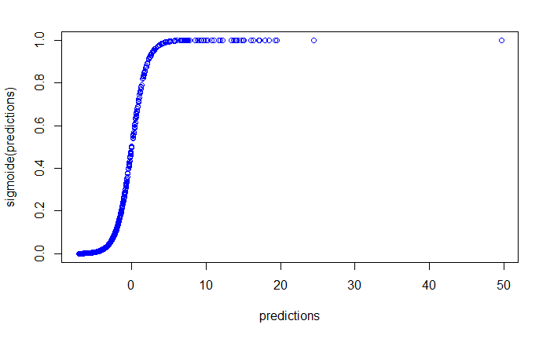

```r
sigmoide=function(x){1/(1+exp(-x))}

plot(predictions,sigmoide(predictions),col="blue")
```

```r
mod_pred<-ifelse(predictions>0.5,1,0)
```

```r
mod_pred<-factor(mod_pred)

head(mod_pred)
```

```
 5  6  9 12 18 24
 0  1  0  0  1  0
Levels: 0 1
```

```r
de$lujo_si<-factor(de$lujo_si)

head(de$lujo_si)
```

```
[1] 0 0 0 0 1 0
Levels: 0 1
```

```r
confusionMatrix(mod_pred,de$lujo_si)
```

```
Confusion Matrix and Statistics

          Reference
Prediction    0    1
         0 1023   64
         1   18  145

               Accuracy : 0.9344
                 95% CI : (0.9192, 0.9475)
    No Information Rate : 0.8328
    P-Value [Acc > NIR] : < 2.2e-16

                  Kappa : 0.7417

 Mcnemar's Test P-Value : 6.715e-07

            Sensitivity : 0.9827
            Specificity : 0.6938
         Pos Pred Value : 0.9411
         Neg Pred Value : 0.8896
             Prevalence : 0.8328
         Detection Rate : 0.8184
   Detection Prevalence : 0.8696
      Balanced Accuracy : 0.8382

       'Positive' Class : 0
```

# 7. Comparación de precios de autos con el dataset

Se hizo un scrape de precios de algunas marcas de lujo

```r
car_prices<-readxl::read_excel("Scrapes.xlsx")
head(car_prices)
```

| Modelo | Marca | Price |
| --- | --- | --- |
| X3 | BMW | 49990 |
| Serie 2 Coupé | BMW | 32990 |
| X5 | BMW | 84990 |
| Raptor | Ford | 87990 |
| Ecosport | Ford | 22890 |
| Ecosport | Ford | 24190 |

```r
dim(car_prices)
```

```
[1] 46  3
```

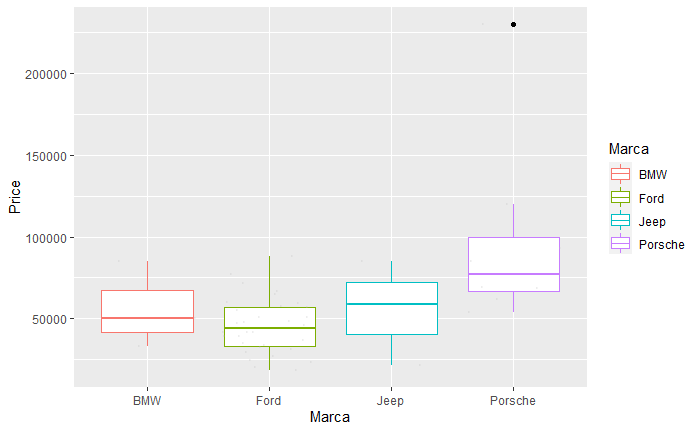

```r
ggplot(car_prices,aes(x=Marca,y=Price,color=Marca))+
  geom_boxplot(outlier.colour = "black",notch = FALSE)+
  scale_fill_viridis(discrete = TRUE, alpha=0.6) +
  geom_jitter(color="gray", size=0.4, alpha=0.15)
```

| mean(Price) | median(Price) | min(Price) | max(Price) |
| --- | --- | --- | --- |
| 55976.52 | 50490 | 18490 | 230000 |

```r
db%>% filter(lujo_si==1)%>%summarise(mean(carvalue),median(carvalue),min(carvalue),max(carvalue))
```

| mean(carvalue) | median(carvalue) | min(carvalue) | max(carvalue) |
| --- | --- | --- | --- |
| 62.27706 | 57.5 | 40 | 99.6 |

```r
NA
NA
```